# Assignment 7 - Extra Credits: Practice dplyr and ggplot2

*How to do it?*:

- Open the Rmarkdown file of this assignment (link) in Rstudio.
- Right under each **question**, insert a code chunk (you can use the hotkey `Ctrl + Alt + I` to add a code chunk) and code the solution for the question.
- `Knit` the rmarkdown file (hotkey: `Ctrl + Alt + K`) to export an html.
- Publish the html file to your Githiub Page.

*Submission*: Submit the link on Github of the assignment to Canvas

1. Import the data at https://bryantstats.github.io/math421/data/ds_salaries.csv

   The data description can be found at https://www.kaggle.com/datasets/saurabhshahane/data-science-jobs-salaries

```r
library(tidyverse)
df <- read_csv("ds_salaries.csv")
```

2. Is there any column that contains NAs?

```r
colSums(is.na(df))
```

```
##          work_year   experience_level    employment_type          job_title
##                  0                  0                  0                  0
##             salary    salary_currency      salary_in_usd employee_residence
##                  0                  0                  0                  0
##       remote_ratio   company_location       company_size
##                  0                  0                  0
```

3. What is the most frequent job title in the data?

```r
df %>%
  count(job_title) %>%
  arrange(-n)
```

```
## # A tibble: 50 × 2
##    job_title                      n
##    <chr>                      <int>
##  1 Data Scientist               143
##  2 Data Engineer                132
##  3 Data Analyst                  97
##  4 Machine Learning Engineer     41
##  5 Research Scientist            16
##  6 Data Science Manager          12
##  7 Data Architect                11
##  8 Big Data Engineer              8
##  9 Machine Learning Scientist     8
## 10 AI Scientist                   7
## # ℹ 40 more rows
```

4. Find the average salary data of the three most frequent job titles in the data.

```r
df %>%
  filter(job_title=='Data Scientist' | job_title=='Data Engineer' | job_title=='Data Analyst') %>%
  summarise(mean_salary = mean(salary))
```

```
## # A tibble: 1 × 1
##   mean_salary
##         <dbl>
## 1     284194.
```

5. What is the job title that have the highest average salary?

```r
df %>%
  group_by(job_title) %>%
  summarise(mean_salary = mean(salary)) %>%
  arrange(-mean_salary)
```

```
## # A tibble: 50 × 2
##    job_title                     mean_salary
##    <chr>                               <dbl>
##  1 Head of Machine Learning         6000000
##  2 ML Engineer                      2676667.
##  3 BI Data Analyst                  1902045.
##  4 Lead Data Scientist              1101667.
##  5 Data Science Manager             1062599.
##  6 Lead Data Analyst                 569000
##  7 Data Scientist                    508347.
##  8 Big Data Engineer                 455000
##  9 Data Analytics Lead               405000
## 10 3D Computer Vision Researcher     400000
## # ℹ 40 more rows
```

6. Which country gives the highest salary on average?

```r
df %>%
  group_by(company_location) %>%
  summarise(mean_salary = mean(salary)) %>%
  arrange(-mean_salary)
```

```
## # A tibble: 50 × 2
##    company_location mean_salary
##    <chr>                  <dbl>
##  1 CL                 30400000
##  2 HU                 11000000
##  3 JP                  3408667.
##  4 IN                  2065208.
##  5 AS                  1335000
##  6 MX                   279333.
##  7 CH                   275000
##  8 CN                   199500
##  9 US                   187716.
## 10 DK                   185000
## # ℹ 40 more rows
```

7. Plot five meaningful plots. All plots should have title, caption, and appropriate labels.

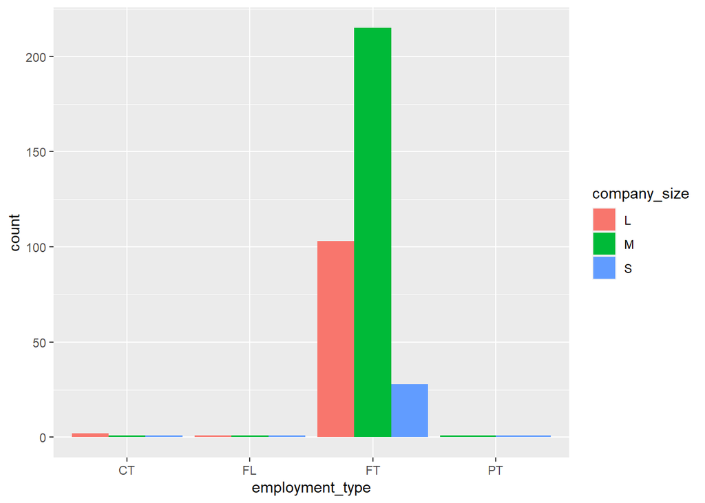

```r
df %>% filter(company_location=='US') %>% ggplot()+
  geom_bar(mapping=aes(x=employment_type, fill=company_size),
           position = 'dodge')
```

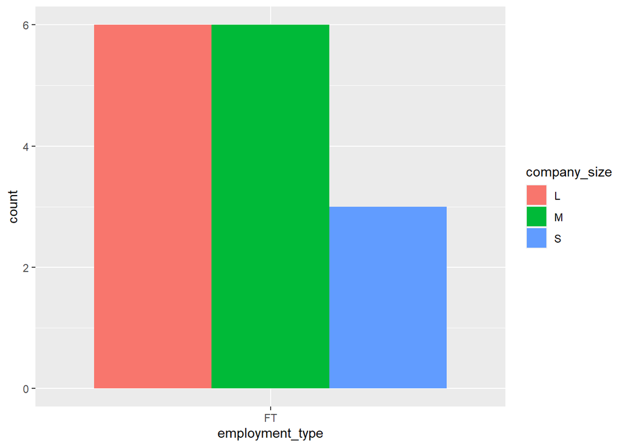

```r
df %>% filter(company_location=='FR') %>% ggplot()+
  geom_bar(mapping=aes(x=employment_type, fill=company_size),
           position = 'dodge')
```

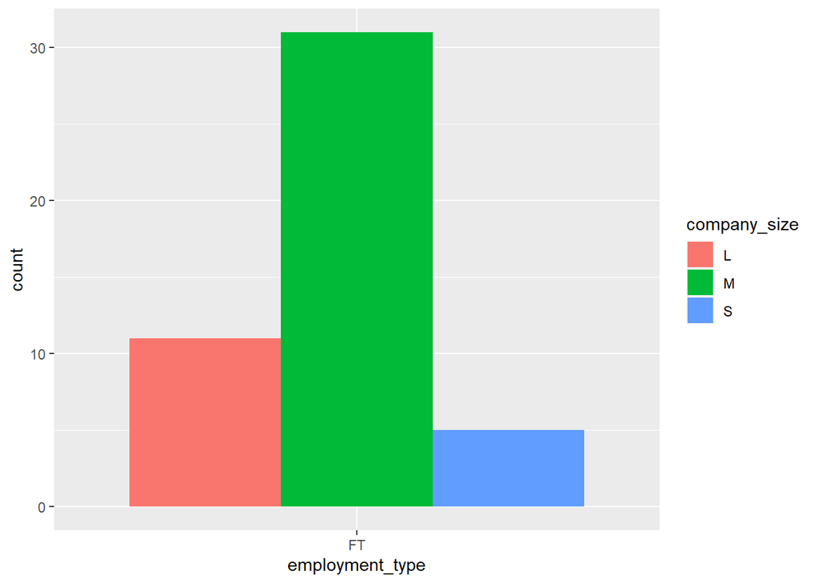

```r
df %>% filter(company_location=='GB') %>% ggplot()+
  geom_bar(mapping=aes(x=employment_type, fill=company_size),
           position = 'dodge')
```

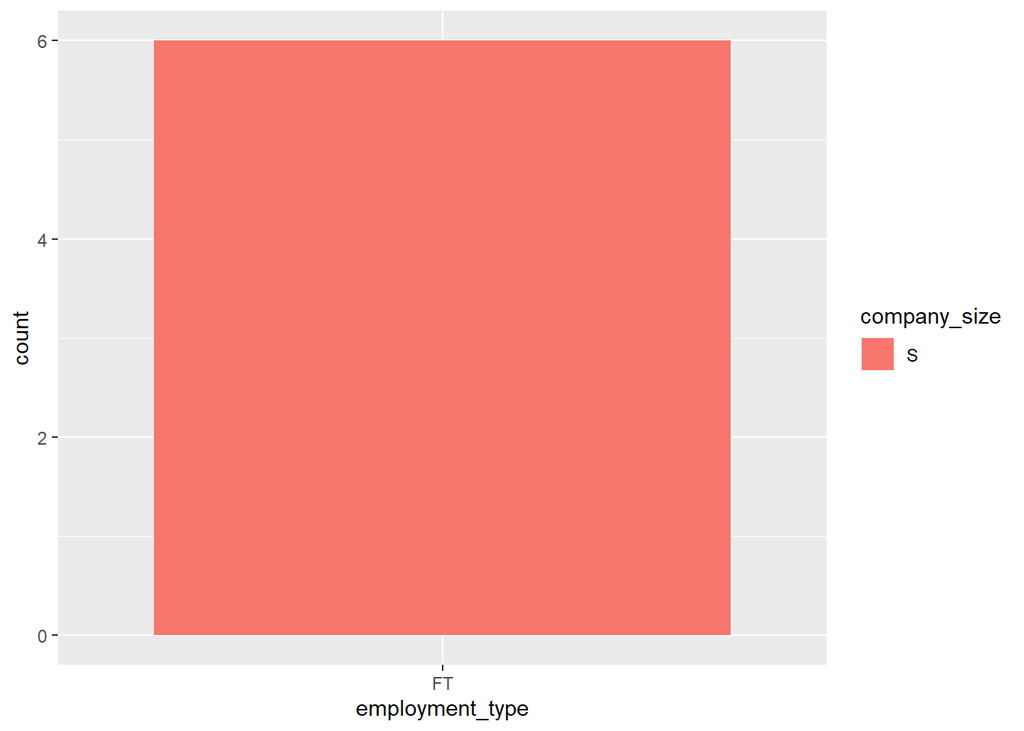

```r
df %>% filter(company_location=='JP') %>% ggplot()+
  geom_bar(mapping=aes(x=employment_type, fill=company_size),
           position = 'dodge')
```

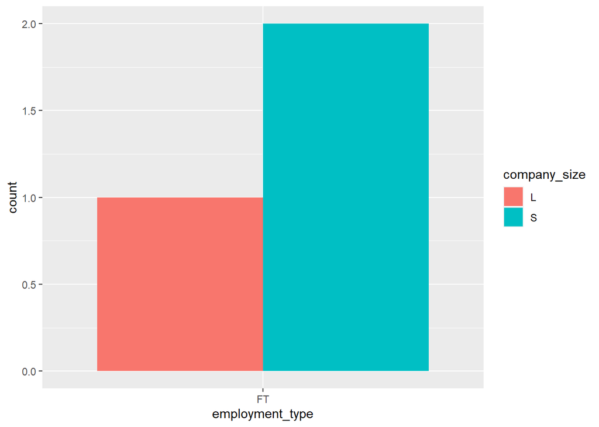

```r
df %>% filter(company_location=='MX') %>% ggplot()+
  geom_bar(mapping=aes(x=employment_type, fill=company_size),
           position = 'dodge')
```